# Fellowship Code

Anil Kemisetti

08/13/2020

#Analysis Description For the fellowship code I am using one of the assignments I have done as the part of the USF biostatistics class.I think it fits the bill perfectly.

For this analysis I will investigate the data in file weather.data.csv We will fit a liner model to the raw data to model the relationship between high daily temperature and month. Then I will create a copy of the raw data and perform data preparation on it. I will then fit a linear model to model the relationship between high daily temperature and month in the new dataset and compare the two models.

Data can be downloaded from this link https://github.com/akemisetti/akemisetti.github.io/blob/master/mshi/631/AnalysisReports/weather.data.csv

#Initial Setup ##Loading the Libraries

```r
setwd("~/")
library(ggplot2)
library(dplyr)
library(kableExtra)
library(data.table)
library(psych)
library(tidyr)
library(car)
library(purrr)
library(ggpubr)
library(gridExtra)
library(grid)
library(corrplot)
library(GGally)
library(ggfortify)
library(cowplot)
library(ggstatsplot)
library(nortest)
library(ggfortify)
library(ggcorrplot)
library(broom)
library(jtools)
library(RColorBrewer)
library(paletteer)
```

#Exploratory Data Analysis

## Reading the data and looking at it for the first time.

### Numerical EDA

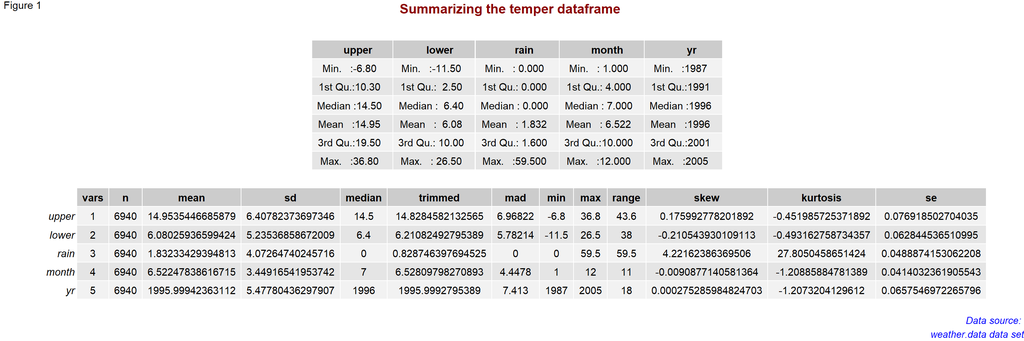

```r
temper <- read.csv("weather.data.csv")
p1 <- ggtexttable(summary(temper))
p2 <- ggtexttable(describe(temper))

annotate_figure(plot_grid(p1,p2, nrow=2) ,
               top = text_grob("Summarizing the temper dataframe \n", color="darkred", face = "bold", size = 14),
               bottom = text_grob("Data source: \n weather.data data set", color = "blue",
                                  hjust = 1, x = 1, face = "italic", size = 10),
               fig.lab = "Figure 1"
)
```

### Visual EDA

#### Univatiate Analysis

Visualing the continious variables

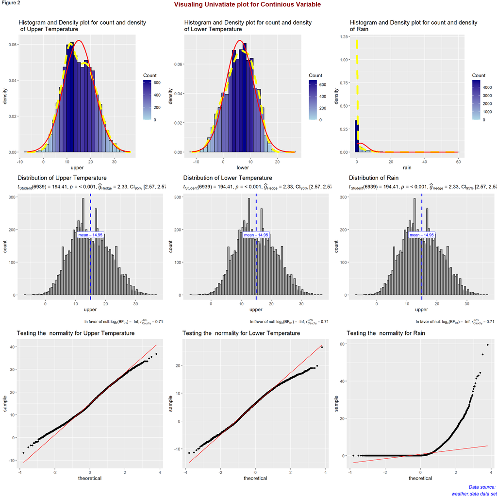

```r
p1 <- ggplot(temper, aes(x=upper))+ geom_histogram( colour="black", aes(y=..density.., fill=..count..))+
      geom_density(linetype = "dashed", color="yellow", size=2)+
      scale_fill_gradient("Count", low="lightblue", high="darkblue") +stat_function(fun=dnorm,color="red", size=1,
                         args=list(mean=mean(temper$upper),
                                  sd=sd(temper$upper))) +ggtitle("Histogram and Density plot for count and density \n of Upper Temperature") + theme_gray()

p2 <- ggplot(temper, aes(x=lower))+ geom_histogram( colour="black", aes(y=..density.., fill=..count..))+
      geom_density(linetype = "dashed", color="yellow", size=2)+
      scale_fill_gradient("Count", low="lightblue", high="darkblue") +stat_function(fun=dnorm,color="red", size=1,
                         args=list(mean=mean(temper$lower),
                                  sd=sd(temper$lower))) +ggtitle("Histogram and Density plot for count and density \nof Lower Temperature") + theme_gray()

p3 <- ggplot(temper, aes(x=rain))+ geom_histogram( colour="black", aes(y=..density.., fill=..count..))+
      geom_density(linetype = "dashed", color="yellow", size=2)+
      scale_fill_gradient("Count", low="lightblue", high="darkblue") +stat_function(fun=dnorm,color="red", size=1,
                         args=list(mean=mean(temper$rain),
                                  sd=sd(temper$rain)))  +ggtitle("Histogram and Density plot for count and density \nof Rain") + theme_gray()

p4 <-gghistostats(
     data = temper,
     x = upper,
     title = "Distribution of Upper Temperature",
    fill.gradient = TRUE,
    messages = FALSE,
    ggstatsplot.layer = FALSE
) +theme_gray()

p5 <-gghistostats(
     data = temper,
     x = upper,
     title = "Distribution of Lower Temperature",
    fill.gradient = TRUE,
    messages = FALSE,
    ggstatsplot.layer = FALSE
) +theme_gray()

p6 <-gghistostats(
     data = temper,
     x = upper,
     title = "Distribution of Rain",
    fill.gradient = TRUE,
    messages = FALSE,
    ggstatsplot.layer = FALSE
) +theme_gray()

p7 <- ggplot(temper, aes(sample = temper$upper))+stat_qq() + stat_qq_line(color = "red") +ggtitle("Testing the  normality for Upper Temperature") +theme_gray()
p8 <- ggplot(temper, aes(sample = temper$lower))+stat_qq() + stat_qq_line(color="red") +ggtitle("Testing the  normality for Lower Temperature") +theme_gray()
p9 <- ggplot(temper, aes(sample = temper$rain))+stat_qq() + stat_qq_line(color ="red") +ggtitle("Testing the  normality for Rain") +theme_gray()

annotate_figure(plot_grid(p1,p2,p3,p4,p5,p6,p7,p8,p9, ncol=3) ,
               top = text_grob("Visualing Univatiate plot for Continious Variable \n", color="darkred", face = "bold", size = 14),
               bottom = text_grob("Data source: \n weather.data data set", color = "blue",
                                  hjust = 1, x = 1, face = "italic", size = 10),
               fig.lab = "Figure 2"
)
```

Normality test for the continious Variables

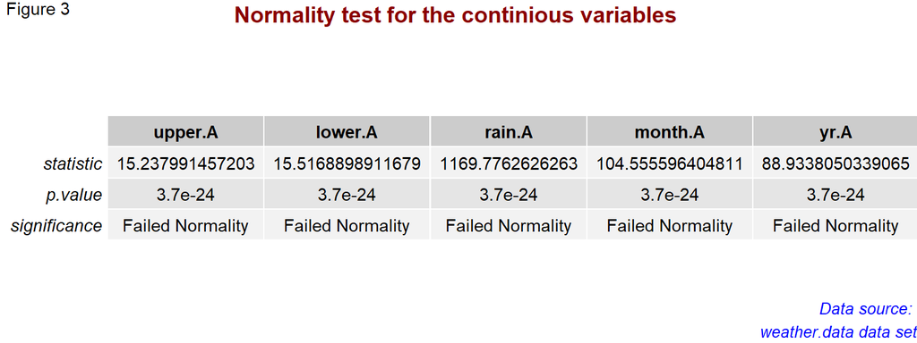

```r
ad_test_df <- function(df, alpha= 0.05) {
  l <- lapply(df, ad.test)
  s <- do.call("c", lapply(l, "[[", 1))
  p <- do.call("c", lapply(l, "[[", 2))
  sig <- ifelse(p > alpha, "Passed Normality", "Failed Normality")

  return(list(statistic= s,
              p.value= p,
              significance= sig
              ))
}
t <- ad_test_df(temper)
p1 <- ggtexttable(do.call(rbind,t))
annotate_figure(plot_grid(p1, ncol=1) ,
               top = text_grob("Normality test for the continious variables \n", color="darkred", face = "bold", size = 14),
               bottom = text_grob("Data source: \n weather.data data set", color = "blue",
                                  hjust = 1, x = 1, face = "italic", size = 10),
               fig.lab = "Figure 3")
```

Numerical Description of the discrete variables

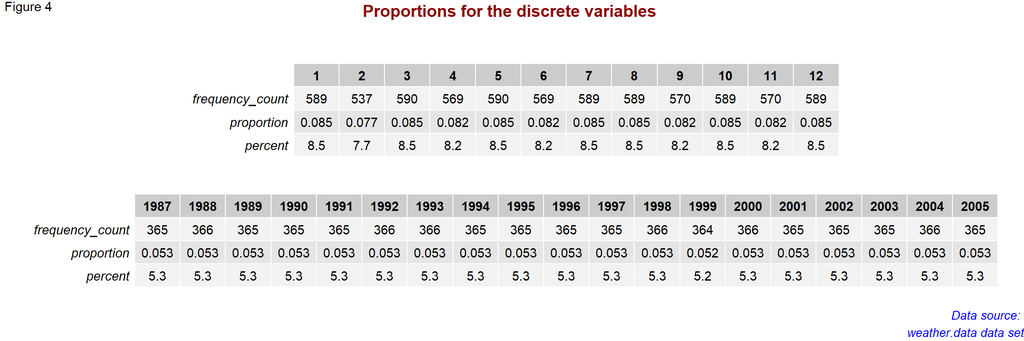

```r
message_function <- function(){'Variable is not discrete ignoring'}
cat_data <- function(x){
  frequency_count <- table(x)
  proportion <- round(frequency_count/sum(frequency_count),3)
  percent <- round(proportion*100,3)
  return (rbind(frequency_count,proportion,percent))
}
t <- lapply(temper, function(x) {
    if (is.integer(x)){ return(cat_data(x))}
    else{ return(message_function())}
})
p1<- ggtexttable(t$month)
p2 <- ggtexttable(t$yr)

annotate_figure(plot_grid(p1,p2, ncol=1) ,
               top = text_grob("Proportions for the discrete variables \n", color="darkred", face = "bold", size = 14),
               bottom = text_grob("Data source: \n weather.data data set", color = "blue",
                                  hjust = 1, x = 1, face = "italic", size = 10),
               fig.lab = "Figure 4"
)
```

Visualizing the Discrete variables

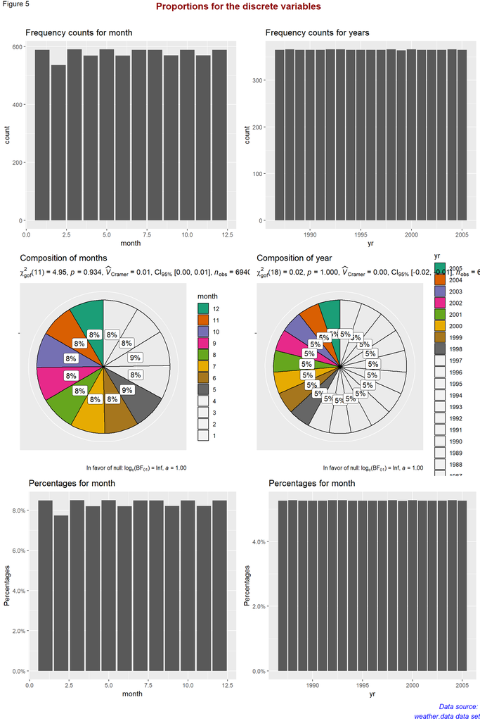

```r
p1 <- ggplot(temper, aes(month)) + geom_bar() + ggtitle("Frequency counts for month") +theme_gray()
p2 <- ggplot(temper, aes(yr)) + geom_bar() + ggtitle("Frequency counts for years")+theme_gray()
p3 <- ggpiestats( data = temper,
  main = month,
  title = "Composition of months",
  messages = FALSE
)+theme_gray()
p4 <- ggpiestats( data = temper,
  main = yr,
  title = "Composition of year",
  messages = FALSE
)+theme_gray()
p5 <- ggplot(temper, aes(x=month)) + geom_bar(aes(y=(..count..)/sum(..count..)))+ scale_y_continuous(labels=scales::percent) +ylab("Percentages") + ggtitle("Percentages for month") +theme_gray()
p6 <- ggplot(temper, aes(x=yr)) + geom_bar(aes(y=(..count..)/sum(..count..)))+ scale_y_continuous(labels=scales::percent) +ylab("Percentages") + ggtitle("Percentages for month")+theme_gray()

annotate_figure(plot_grid(p1,p2,p3,p4,p5,p6, ncol=2) ,
               top = text_grob("Proportions for the discrete variables \n", color="darkred", face = "bold", size = 14),
               bottom = text_grob("Data source: \n weather.data data set", color = "blue",
                                  hjust = 1, x = 1, face = "italic", size = 10),
               fig.lab = "Figure 5"
)
```

#### Bivariarte Analysis

Correlation Analysis of the bi-variate analysis. Correlation Matrix of all the variables

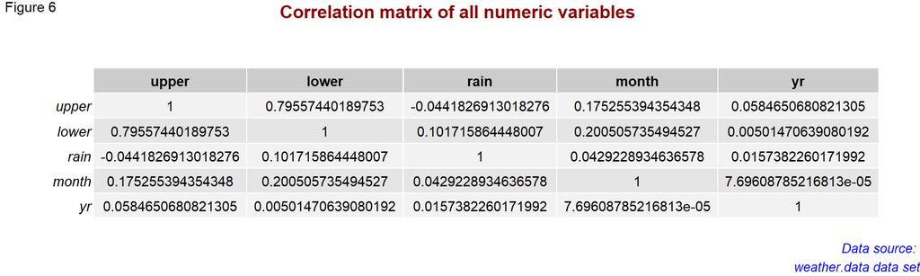

```r
p1 <- ggtexttable(cor(temper)) + ggtitle("Correlation matrix")

annotate_figure(plot_grid(p1, ncol=1) ,
               top = text_grob("Correlation matrix of all numeric variables \n", color="darkred", face = "bold", size = 14),
               bottom = text_grob("Data source: \n weather.data data set", color = "blue",
                                  hjust = 1, x = 1, face = "italic", size = 10),
               fig.lab = "Figure 6"
)
```

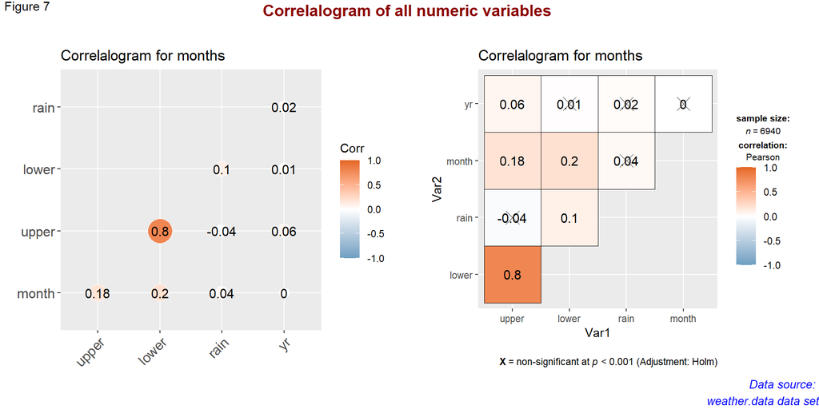

```r
p1 <- ggcorrplot(cor(temper), hc.order = TRUE,  type = "lower",
       outline.col = "white",
       method = "circle",
       lab = TRUE,
       ggtheme = ggplot2::theme_gray,
       colors = c("#6D9EC1", "white", "#E46726")) + ggtitle("Correlalogram for months")
capture.output(p2 <- ggcorrmat(
  data =temper,
  corr.method = "robust",
  sig.level = 0.001,
  p.adjust.method = "holm",
  cor.vars = c(upper,lower,rain,month,yr),
  matrix.type = "upper",
  colors = c("#6D9EC1", "white", "#E46726"),
  title = "Correlalogram for months",
  messages = FALSE
) +theme_gray(),file = 'NUL')

annotate_figure(plot_grid(p1,p2, nrow = 1) ,
               top = text_grob("Correlalogram of all numeric variables \n", color="darkred", face = "bold", size = 14),
               bottom = text_grob("Data source: \n weather.data data set", color = "blue",
                                  hjust = 1, x = 1, face = "italic", size = 10),
               fig.lab = "Figure 7"
)
```

Plotting the regression for every pair of the variables.

```r
regression_fn <- function(data, mapping, method, ...){
      ggplot(data = data, mapping = mapping) +
      geom_point() +
      geom_smooth(method=method, ...)
    }
p1 <- ggpairs(temper, diag = list(continious = "barDiag"), lower= list(continuous = wrap(regression_fn, method="lm") ), upper= list(continuous = wrap(regression_fn, method = "loess") )) + ggtitle("Bi Variate plot of all the variables") + theme_gray()
f <- ggmatrix_gtable(p1,nrow=1)
capture.output(annotate_figure(f ,
               top = text_grob("Regressiion plot of all pairs of variables \n", color="darkred", face = "bold", size = 14),
               bottom = text_grob("Data source: \n weather.data data set", color = "blue",
                                  hjust = 1, x = 1, face = "italic", size = 10),
               fig.lab = "Figure 8"
),file = 'NUL')
```

[figure not shown]

#Regression Analysis Performing regression analysis of the model fitting the upper as a function of month and creating the summary of the model.

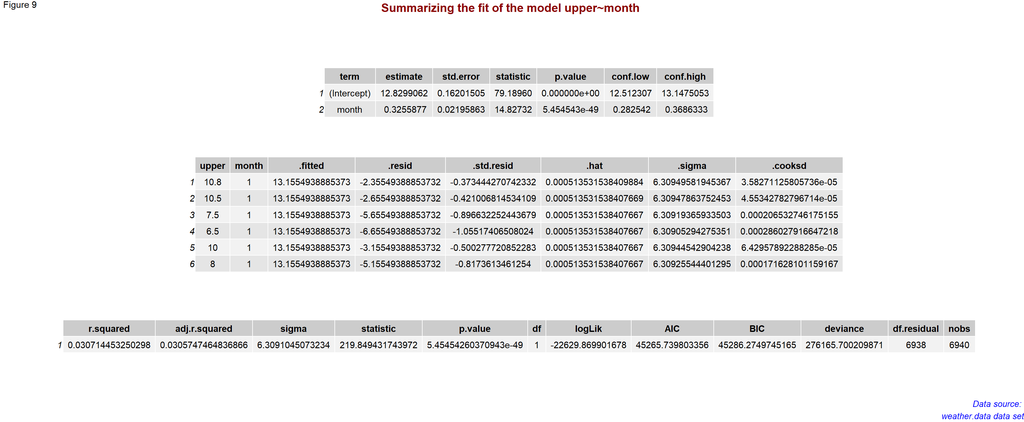

```r
fit0 <- lm(upper~month, data = temper)
t <- tidy(fit0, conf.int = TRUE)
p1 <- ggtexttable(t)
p2 <- ggtexttable(head(augment(fit0)))
p3 <- ggtexttable(glance(fit0))

annotate_figure(plot_grid(p1,p2,p3, nrow=3) ,
               top = text_grob("Summarizing the fit of the model upper~month \n", color="darkred", face = "bold", size = 14),
               bottom = text_grob("Data source: \n weather.data data set", color = "blue",
                                  hjust = 1, x = 1, face = "italic", size = 10),
               fig.lab = "Figure 9"
)
```

Plotting the model details

```r
p1 <- ggplot(temper, aes(x=month,y = upper, color=month))+ geom_point() + geom_abline(slope = t$estimate[2], intercept = t$estimate[1],color="red",size=1)  + ggtitle("Plotting Regression Line") + theme_gray()
p2 <- ggplot(t, aes(estimate, term, color = term)) + geom_point() + geom_errorbarh(aes(xmin = conf.low, xmax = conf.high)) +geom_vline(xintercept = 0)  + ggtitle("Plotting Regression coefficients") + theme_gray()
p3 <- ggcoefstats(x = fit0) + ggtitle("Plotting Regression coefficients") + theme_gray()
```

```
## * NA -> ...1
## * NA -> ...2
## * NA -> ...3
## * NA -> ...4
```

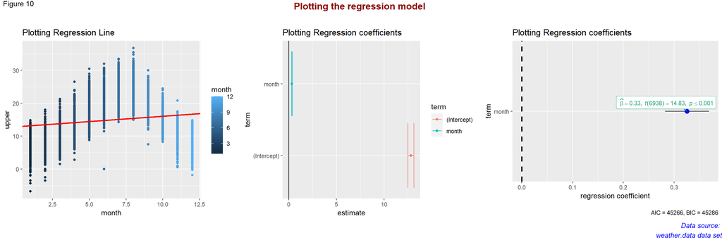

```r
annotate_figure(plot_grid(p1,p2,p3, nrow=1) ,
               top = text_grob("Plotting the regression model \n", color="darkred", face = "bold", size = 14),
               bottom = text_grob("Data source: \n weather.data data set", color = "blue",
                                  hjust = 1, x = 1, face = "italic", size = 10),
               fig.lab = "Figure 10"
)
```

Plotting the results of Regression

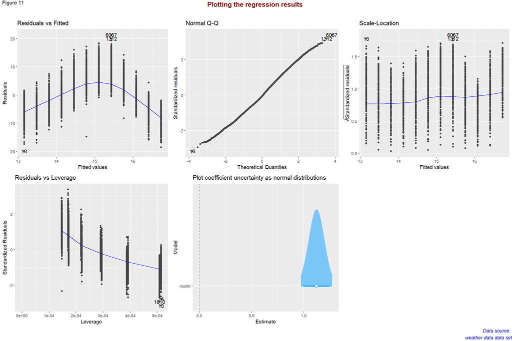

```r
p <- autoplot(fit0, ncol =4) + theme_gray()
p1 <- plot_summs(fit0, scale = TRUE, plot.distributions = TRUE, inner_ci_level = .9) + theme_gray() +ggtitle("Plot coefficient uncertainty as normal distributions")

annotate_figure(plot_grid(p[[1]],p[[2]],p[[3]],p[[4]],p1,ncol = 3),
               top = text_grob("Plotting the regression results \n", color="darkred", face = "bold", size = 14),
               bottom = text_grob("Data source: \n weather.data data set", color = "blue",
                                  hjust = 1, x = 1, face = "italic", size = 10),
               fig.lab = "Figure 11"
)
```

```r
cat('Equation for fit0 is upper = ',t$estimate[2],'* month + ',t$estimate[1] )
```

```
## Equation for fit0 is upper =  0.3255877 * month +  12.82991
```

# Modifying the dataset

Initial observation was made that month and year are not discrete numbers but are factor variables. Converting them into factor variables.

```r
temper2 <- temper
lab = c("Jan", "Feb", "Mar","Apr", "May", "Jun","July", "Aug", "Sep","Oct", "Nov", "Dec")
temper2$month <- factor(temper$month, labels=lab)
temper2$yr <- factor(temper$yr)
```

Describing temper2 numerically

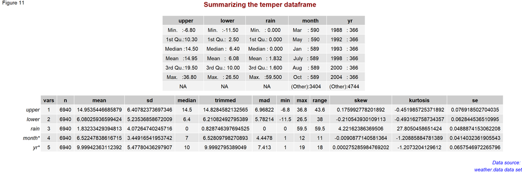

```r
p1 <- ggtexttable(summary(temper2))
p2 <- ggtexttable(describe(temper2))

annotate_figure(plot_grid(p1,p2, nrow=2) ,
               top = text_grob("Summarizing the temper dataframe \n", color="darkred", face = "bold", size = 14),
               bottom = text_grob("Data source: \n weather.data data set", color = "blue",
                                  hjust = 1, x = 1, face = "italic", size = 10),
               fig.lab = "Figure 11"
)
```

Plotting the regression for every pair of the variables.

```r
p1 <- ggpairs(temper2, diag = list(continious = "barDiag"), lower= list(continuous = wrap(regression_fn, method="lm") ), upper= list(continuous = wrap(regression_fn, method = "loess") ), cardinality_threshold = 19) +
  ggtitle("Bi Variate plot of all the variables") + theme_gray()
f <- ggmatrix_gtable(p1,nrow=1)
capture.output(annotate_figure(f ,
               top = text_grob("Regressiion plot of all pairs of variables \n", color="darkred", face = "bold", size = 14),
               bottom = text_grob("Data source: \n weather.data data set", color = "blue",
                                  hjust = 1, x = 1, face = "italic", size = 10),
               fig.lab = "Figure 12"
),file = 'NUL')
```

[figure not shown]

#Regression Analysis Performing regression analysis of the model fitting the upper as a function of month and creating the summary of the model.

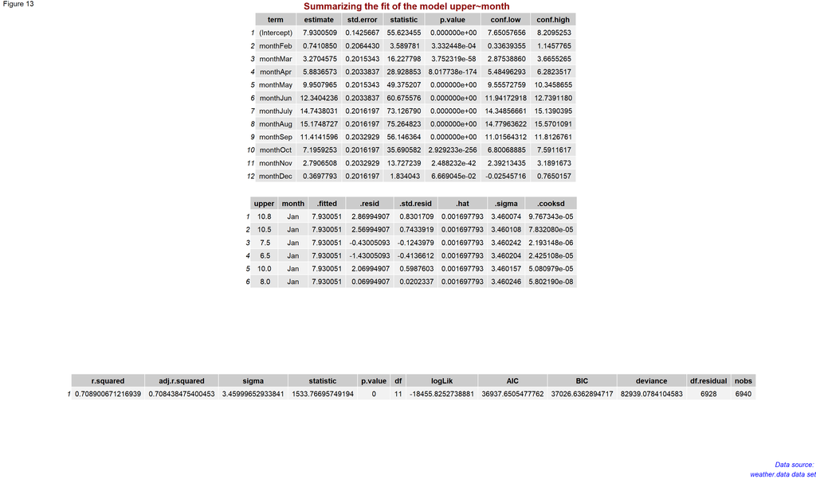

```r
fit1 <- lm(upper~month, data = temper2)
t1 <- tidy(fit1, conf.int = TRUE)
p1 <- ggtexttable(t1)
p2 <- ggtexttable(head(augment(fit1)))
p3 <- ggtexttable(glance(fit1))

annotate_figure(plot_grid(p1,p2,p3, nrow=3) ,
               top = text_grob("Summarizing the fit of the model upper~month \n", color="darkred", face = "bold", size = 14),
               bottom = text_grob("Data source: \n weather.data data set", color = "blue",
                                  hjust = 1, x = 1, face = "italic", size = 10),
               fig.lab = "Figure 13"
)
```

Plotting the model details

```r
color <- grDevices::colors()[grep('gr(a|e)y', grDevices::colors(), invert = T)]
slp <- c(0,t1$estimate[2:12])
mon <- c(1,2,3,4,5,6,7,8,9,10,11,12)
ccc <- sample(color, 12)
incpt=rep(t1$estimate[1],12)
incpt_calc <- slp+incpt
color_dt <- data.frame(month=lab,ccc=ccc,slp=slp,incpt=incpt,mon=mon,incpt_calc=incpt_calc)
color_dt
```

```
##    month             ccc        slp    incpt mon incpt_calc
## 1    Jan       royalblue  0.0000000 7.930051   1   7.930051
## 2    Feb         oldlace  0.7410850 7.930051   2   8.671136
## 3    Mar      peachpuff3  3.2704575 7.930051   3  11.200508
## 4    Apr          azure1  5.8836573 7.930051   4  13.813708
## 5    May     dodgerblue2  9.9507965 7.930051   5  17.880847
## 6    Jun         orchid3 12.3404236 7.930051   6  20.270475
## 7   July           gold4 14.7438031 7.930051   7  22.673854
## 8    Aug       seashell4 15.1748727 7.930051   8  23.104924
## 9    Sep          ivory4 11.4141596 7.930051   9  19.344211
## 10   Oct mediumvioletred  7.1959253 7.930051  10  15.125976
## 11   Nov      chocolate1  2.7906508 7.930051  11  10.720702
## 12   Dec        hotpink1  0.3697793 7.930051  12   8.299830
```

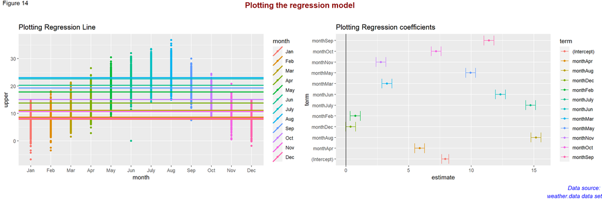

```r
temper3 <- merge(temper2,color_dt,by="month")
p1 <- ggplot(temper3, aes(x=month,y = upper,color=month))+ geom_point() + geom_abline( mapping = aes(slope = 0, intercept = incpt_calc,color=month),size=1)  + ggtitle("Plotting Regression Line") + theme_gray()
p2 <- ggplot(t1, aes(estimate, term, color = term)) + geom_point() + geom_errorbarh(aes(xmin = conf.low, xmax = conf.high)) +geom_vline(xintercept = 0)  + ggtitle("Plotting Regression coefficients") + theme_gray()

annotate_figure(plot_grid(p1,p2, nrow=1) ,
               top = text_grob("Plotting the regression model \n", color="darkred", face = "bold", size = 14),
               bottom = text_grob("Data source: \n weather.data data set", color = "blue",
                                  hjust = 1, x = 1, face = "italic", size = 10),
               fig.lab = "Figure 14"
)
```

Plotting the results of Regression

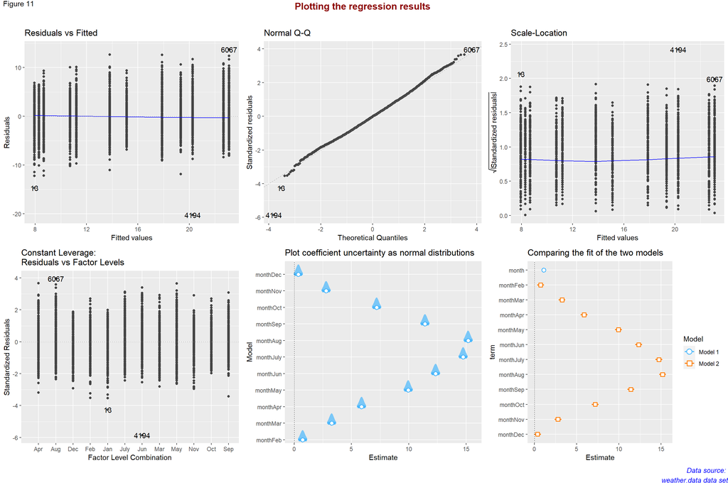

```r
p <- autoplot(fit1, ncol =4) + theme_gray()
p1 <- plot_summs(fit1, scale = TRUE, plot.distributions = TRUE, inner_ci_level = .9) + theme_gray() +ggtitle("Plot coefficient uncertainty as normal distributions")
p2 <- plot_summs(fit0, fit1, scale = TRUE) +ggtitle("Comparing the fit of the two models")+ theme_gray()

annotate_figure(plot_grid(p[[1]],p[[2]],p[[3]],p[[4]],p1,p2,ncol = 3),
               top = text_grob("Plotting the regression results \n", color="darkred", face = "bold", size = 14),
               bottom = text_grob("Data source: \n weather.data data set", color = "blue",
                                  hjust = 1, x = 1, face = "italic", size = 10),
               fig.lab = "Figure 11"
)
```

creating equations for all the months

```r
call_func <- function(x) cat('Equation for month ',x[1],' is ',x[4],'+',x[3],"\n")
apply(color_dt,1,call_func)
```

```
## Equation for month  Jan  is  7.930051 +  0.0000000
## Equation for month  Feb  is  7.930051 +  0.7410850
## Equation for month  Mar  is  7.930051 +  3.2704575
## Equation for month  Apr  is  7.930051 +  5.8836573
## Equation for month  May  is  7.930051 +  9.9507965
## Equation for month  Jun  is  7.930051 + 12.3404236
## Equation for month  July  is  7.930051 + 14.7438031
## Equation for month  Aug  is  7.930051 + 15.1748727
## Equation for month  Sep  is  7.930051 + 11.4141596
## Equation for month  Oct  is  7.930051 +  7.1959253
## Equation for month  Nov  is  7.930051 +  2.7906508
## Equation for month  Dec  is  7.930051 +  0.3697793
```

### About the final model.

r-Squared of the first model was 0.0307 and it improved in the second model and the adjusted R-squared value is 0.708. It has also improved the explained variance shown in the Residual Vs Fitted Plot.